# Unboxing the blackbox: basics

Date: May 22, 2020

Table of contents:

- Setting up and built in standard model
- Recreating nn.ReLU
- Recreating nn.Linear
- Recreating nn.CrossEntropyLoss
- nn.CrossEntropyLoss alternatives and analysis
- Recreating nn.BCEWithLogitsLoss
- Creating an optimizer

Today, we will be building pretty much everything from scratch. The only functionalities we will borrow from PyTorch are low level tensor-related operations and autograd. Let's get right in and import a bunch of stuff:

## Setting up and built in standard model

```python
import torch
import numpy as np
import matplotlib.pyplot as plt
import torch.nn as nn

import torchvision.datasets as datasets
import torchvision
import torch.optim as optim
import time
```

Let's import our MNIST images:

```python
dl = torch.utils.data.DataLoader(datasets.MNIST("datasets/", download=True,
                                 transform=torchvision.transforms.Compose([
                                     torchvision.transforms.ToTensor(),
                                     torchvision.transforms.Normalize((0.1307,), (0.3081,))
                                 ])), batch_size=1000, shuffle=True)
dl_test = torch.utils.data.DataLoader(datasets.MNIST("datasets/", download=True, train=False,
                                 transform=torchvision.transforms.Compose([
                                     torchvision.transforms.ToTensor(),
                                     torchvision.transforms.Normalize((0.1307,), (0.3081,))
                                 ])), batch_size=100, shuffle=True)
```

And here are the shapes of it:

```python
imgs, labels = next(iter(dl))
print(f"Images shape: {imgs.shape}, labels shape: {labels.shape}")
print(f"Image range: ({imgs.min()}, {imgs.max()}), average: {imgs.mean()}, std: {imgs.std()}")
print(f"Labels: {labels[:15]}")
```

```
Images shape: torch.Size([1000, 1, 28, 28]), labels shape: torch.Size([1000])
Image range: (-0.4242129623889923, 2.821486711502075), average: 0.00417701993137598, std: 1.005340814590454
Labels: tensor([0, 7, 9, 9, 9, 9, 1, 6, 0, 3, 7, 2, 4, 7, 8])
```

Each minibatch has 1000 samples, each has 1 channel (it's black and white), and the image size is 28 by 28. Then we have 1000 labels to go with. The vanilla dataset's images are actually from 0 to 1, but we have normalized it (using the default transforms), so that the mean is 0 and standard deviation is 1. Let's show a couple of these images:

[figure not shown]

```python
plt.figure(num=None, figsize=(10, 6), dpi=350)
for i in range(15):
    plt.subplot(1, 15, i+1)
    plt.imshow(imgs[i][0])
    plt.axis("off")
```

Let's see how an implementation with everything built in looks like:

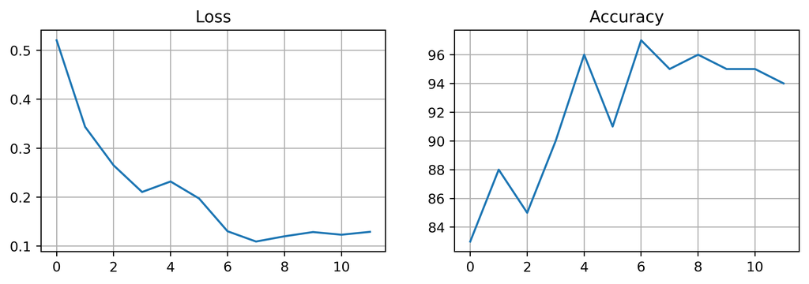

```python
class BuiltInNet(nn.Module):
    def __init__(self):
        super().__init__()
        self.fc1 = nn.Linear(28 * 28, 100)
        self.fc2 = nn.Linear(100, 10)
        self.relu = nn.ReLU()
    def forward(self, x):
        return self.fc2(self.relu(self.fc1(x)))
    def train(self, epochs):
        optimizer = optim.Adam(self.parameters(), 0.01)
        lossFunction = nn.CrossEntropyLoss()
        count, losses, accuracies = 0, [], []
        for epoch in range(epochs):
            for imgs, labels in dl:
                batchSize = len(labels); output = self(imgs.view(-1, 28*28).cuda())
                loss = lossFunction(output, labels.cuda())
                loss.backward(); optimizer.step(); optimizer.zero_grad(); count += 1
                if count % 10 == 0:
                    losses.append(loss.item())
                    test_imgs, test_labels = next(iter(dl_test))
                    output = self(test_imgs.cuda().view(-1, 28*28))
                    accuracies.append((torch.argmax(output, dim=1) == test_labels.cuda()).sum())
        return torch.Tensor(losses), torch.Tensor(accuracies)
losses, accuracies = BuiltInNet().cuda().train(2)
plt.figure(num=None, figsize=(10, 3), dpi=350)
plt.subplot(1, 2, 1); plt.grid(True); plt.plot(losses); plt.title("Loss")
plt.subplot(1, 2, 2); plt.grid(True); plt.plot(accuracies); plt.title("Accuracy"); pass
```

Pretty standard. We have 2 linear layers, one translates 28 * 28 features to 100 features, the other translates 100 to 10 features. Then sandwiched between them is the ReLU activation function, and finally, there's a loss function and an optimizer. All pretty standard. Looks like everything is working.

Now let's deconstruct every magical part one by one, so that we will only use PyTorch's low level tensor manipulation functions and autograd to calculate the gradients for us. The ideal would be to build the autograd feature from scratch too, but that is quite long, specific, involved, complex, and justify a complete post dedicated to itself, so we're not going to do it now.

## Recreating nn.ReLU

This one is super duper easy. Let's poke around with the built in function:

```python
relu = nn.ReLU()
x = torch.rand(15) * 2 - 1
print(f"x: {x}")
print(f"Output: {relu(x)}")
```

```
x: tensor([ 0.1877, -0.7253, -0.2680, -0.5134,  0.3893,  0.3757, -0.0680,  0.2255,
         0.9546, -0.0088,  0.5794,  0.0144,  0.7913,  0.1290,  0.1533])
Output: tensor([0.1877, 0.0000, 0.0000, 0.0000, 0.3893, 0.3757, 0.0000, 0.2255, 0.9546,
        0.0000, 0.5794, 0.0144, 0.7913, 0.1290, 0.1533])
```

As you can see, it just simply sets everything to 0 if the number is less than 0. How can we recreate this behavior? We can loop through every element, check if the element is greater than 0, then add that element to another list, then return.

The problem is that Python is excruciatingly slow. When we were implementing the convolution layer in [a previous post](http://blackbox.nn.157239n.com/conv), the accelerated algorithm is 2 million times faster than the pure python algorithm!! We have to devise a way to utilize PyTorch's Tensor class. We can check for elements that are greater than 0 using:

```python
x > 0
```

```
tensor([ True, False, False, False,  True,  True, False,  True,  True, False,
         True,  True,  True,  True,  True])
```

Yeah it works. `False` is represented with the number 0, and True is represented with the number 1, as you can see here:

```python
(x > 0) + 0
```

```
tensor([1, 0, 0, 0, 1, 1, 0, 1, 1, 0, 1, 1, 1, 1, 1])
```

So, we can use that as a gate to either let the element through or not:

```python
def ReLU(x):
    return (x > 0) * x
ReLU(x)
```

```
tensor([0.1877, -0.0000, -0.0000, -0.0000, 0.3893, 0.3757, -0.0000, 0.2255, 0.9546,
        -0.0000, 0.5794, 0.0144, 0.7913, 0.1290, 0.1533])
```

We probably want to comply with PyTorch's way of creating a module, so here's it:

```python
class ReLU(nn.Module):
    def __init__(self):
        super().__init__()
    def forward(self, x):
        return (x > 0) * x
relu = ReLU()
relu(x)
```

```
tensor([0.1877, -0.0000, -0.0000, -0.0000, 0.3893, 0.3757, -0.0000, 0.2255, 0.9546,
        -0.0000, 0.5794, 0.0144, 0.7913, 0.1290, 0.1533])
```

Yeah it's really that simple.

## Recreating nn.Linear

Let's see the [docs](https://pytorch.org/docs/stable/nn.html#linear) on how this layer works:

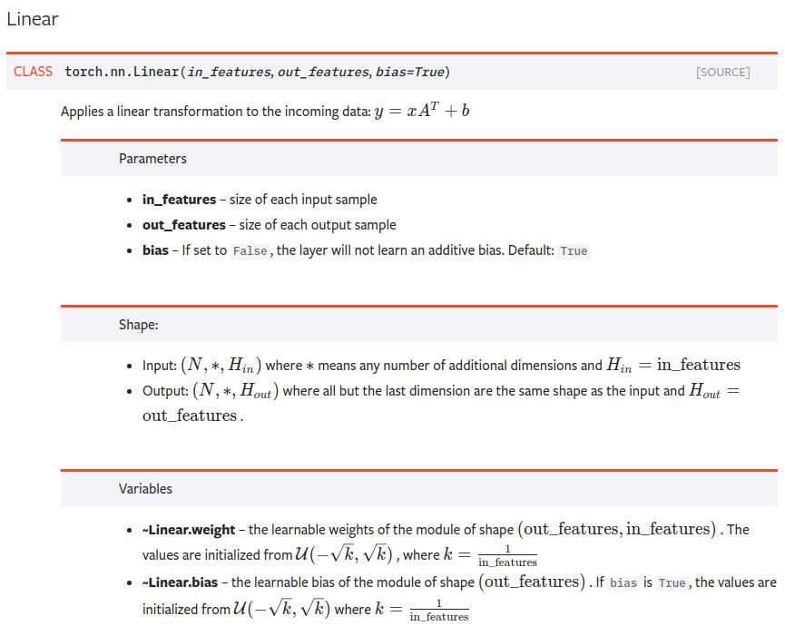

Apparently, there're 2 internal variables: `weight` and `bias`. Let's check them out:

```python
linear = nn.Linear(4, 5)
print(f"Type of weight: {type(linear.weight)}")
print(f"Type of weight.data: {type(linear.weight.data)}")
print(f"Shape of weight.data: {linear.weight.data.shape}")
print(f"Type of bias: {type(linear.bias)}")
print(f"Type of bias.data: {type(linear.bias.data)}")
print(f"Shape of bias.data: {linear.bias.data.shape}")
print(f"Weight: {linear.weight}")
print(f"Sum of weight's columns: {linear.weight.sum(0)}")
```

```
Type of weight: <class 'torch.nn.parameter.Parameter'>
Type of weight.data: <class 'torch.Tensor'>
Shape of weight.data: torch.Size([5, 4])
Type of bias: <class 'torch.nn.parameter.Parameter'>
Type of bias.data: <class 'torch.Tensor'>
Shape of bias.data: torch.Size([5])
Weight: Parameter containing:
tensor([[ 0.3837,  0.1261,  0.4980, -0.3630],
        [-0.2076,  0.2556, -0.3336,  0.0452],
        [-0.3492, -0.3886,  0.0370,  0.1315],
        [ 0.2113,  0.4469,  0.2690, -0.1125],
        [ 0.2304,  0.0031, -0.1229, -0.0168]], requires_grad=True)
Sum of weight's columns: tensor([ 0.2686,  0.4431,  0.3476, -0.3156], grad_fn=<SumBackward1>)
```

Both of them are of type Parameter, which will track gradients for us using PyTorch's autograd feature. Let's check out that autograd feature:

```python
x = torch.rand(10, 4, requires_grad=True)
print(f"x: \n{x}")
print(f"x gradient before: {x.grad}")
y = linear(x).sum()
y.backward()
print(f"y: {y}")
print(f"x gradient after: \n{x.grad}")
print(f"y gradient after: {y.grad}")
```

```
x:
tensor([[0.6812, 0.0620, 0.4334, 0.6831],
        [0.3570, 0.0641, 0.8015, 0.3597],
        [0.5923, 0.1491, 0.4696, 0.9180],
        [0.1041, 0.9563, 0.9434, 0.0025],
        [0.9546, 0.7472, 0.3431, 0.4785],
        [0.9064, 0.9631, 0.9906, 0.5342],
        [0.4778, 0.3102, 0.4551, 0.1741],
        [0.5859, 0.7024, 0.6715, 0.1856],
        [0.6708, 0.1295, 0.8926, 0.0034],
        [0.5657, 0.7576, 0.7531, 0.5079]], requires_grad=True)
x gradient before: None
y: 12.997199058532715
x gradient after:
tensor([[ 0.2686,  0.4431,  0.3476, -0.3156],
        [ 0.2686,  0.4431,  0.3476, -0.3156],
        [ 0.2686,  0.4431,  0.3476, -0.3156],
        [ 0.2686,  0.4431,  0.3476, -0.3156],
        [ 0.2686,  0.4431,  0.3476, -0.3156],
        [ 0.2686,  0.4431,  0.3476, -0.3156],
        [ 0.2686,  0.4431,  0.3476, -0.3156],
        [ 0.2686,  0.4431,  0.3476, -0.3156],
        [ 0.2686,  0.4431,  0.3476, -0.3156],
        [ 0.2686,  0.4431,  0.3476, -0.3156]])
y gradient after: None
```

An interesting thing here. See how the x's gradient have the same lines? And the values of each of those lines is exactly the same as the sum of linear.weight's columns. I won't go more into autograd, but thought I'd just mention here in case you're curious.

What we are focusing on is just the fact that you can pass a tensor through multiple operations (like the linear layer), arrive at a single number, call `backward()` and PyTorch will automatically calculate all gradients of all tensors that track gradients (`requires_grad` field is `True`).

That aside, making this linear layer is pretty easy too. We just need to multiply the input with a tensor, then add a bias:

```python
class Linear(nn.Module):
    def __init__(self, input_features, output_features):
        super().__init__()
        kSqrt = np.sqrt(1/input_features)
        self.weight = nn.Parameter(torch.rand(input_features, output_features)*2*kSqrt-kSqrt)
        self.bias = nn.Parameter(torch.rand(output_features)*2*kSqrt-kSqrt)
    def forward(self, x):
        return x @ self.weight + self.bias
linear = Linear(4, 5)
x = torch.rand(8, 4, requires_grad=True)
print(f"Sum of weight's rows: {linear.weight.sum(1)}")
linear(x).sum().backward()
print(f"x's gradient: \n{x.grad}")
```

```
Sum of weight's rows: tensor([ 0.1281, -0.1202, -0.0430, -0.3822], grad_fn=<SumBackward1>)
x's gradient:
tensor([[ 0.1281, -0.1202, -0.0430, -0.3822],
        [ 0.1281, -0.1202, -0.0430, -0.3822],
        [ 0.1281, -0.1202, -0.0430, -0.3822],
        [ 0.1281, -0.1202, -0.0430, -0.3822],
        [ 0.1281, -0.1202, -0.0430, -0.3822],
        [ 0.1281, -0.1202, -0.0430, -0.3822],
        [ 0.1281, -0.1202, -0.0430, -0.3822],
        [ 0.1281, -0.1202, -0.0430, -0.3822]])
```

There are some interesting things though. The weights are initialized as a uniform distribution of $U\left(-\sqrt\frac{1}{in\_features},\sqrt\frac{1}{in\_features}\right)$. It's not entirely obvious why we do such a thing, but it's a suggested guideline from the ["Understanding the difficulty of training deep feedforward neural networks" paper](http://proceedings.mlr.press/v9/glorot10a/glorot10a.pdf). `torch.rand()` will generate tensor with numbers between 0 and 1 only, so we have to do our own scaling. Also notice how the gradients are now the sum of linear weight's rows, not columns like before, because for some reason, PyTorch's internal weight tensor is of dimension $(out\_features, in\_features)$ and not the way around, which is what we intuitively would think about, but it still works.

## Recreating nn.CrossEntropyLoss

This one is a wee bit more complicated, but should be simple enough. The goal of a loss function is to distill all outputs down to a single number that measures how well the network is doing. Our setup is that after 2 linear layers, we have a $(\#samples, 10)$ tensor. For the moment, we will disregard the #samples part, and just assume the output is a vector of 10 elements. Ideally, we want the network to predict 1 in 10 numbers. So may be we want 10 numbers, all are from 0 to 1 and adds up to 1. This is a good idea, because we can interpret each of the 10 numbers as a percentage closeness to the label. We also want to impose a strict order so that the higher the number, the higher the network thinks that label is correct.

Let's obtain the second property first. Let's grab a random possible output:

```python
output = torch.rand(10) * 40 - 20; output
```

```
tensor([ -5.2781,  17.6041,  18.7785,   1.0791,  -5.7108, -10.8150,  14.1583,
        -14.8016,   1.1255, -15.9778])
```

A nice function that transform the output to positive numbers, with higher numbers transformed to higher numbers is $e^x$. Let's see how it looks like:

```
tensor([5.1022e-03, 4.4193e+07, 1.4302e+08, 2.9421e+00, 3.3099e-03, 2.0096e-05,
        1.4089e+06, 3.7302e-07, 3.0819e+00, 1.1506e-07])
```

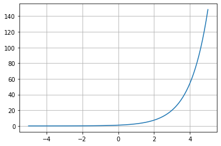

```python
x = torch.linspace(-5, 5, 100)
plt.grid(True); plt.plot(x, torch.exp(x))
torch.exp(output)
```

Now, we want all $e^{output}$ to all add up to 1, how can we do that? $e^{output}$ has 10 numbers, so how about adding up those 10 numbers, then divide each element by that?

```
<BarContainer object of 10 artists>
```

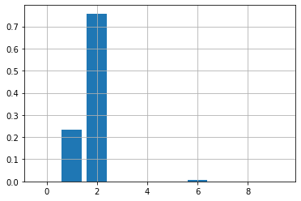

```python
sum = torch.exp(output).sum()
transformedOutput = torch.exp(output)/sum
plt.grid(True)
plt.bar(range(10), transformedOutput)
```

Yeah, looks kinda good. This algorithm is called "Softmax", and the formal mathematical notation is $e^{a_i}\left/\sum e^{a_i}\right.$ Now that we have the probabilities for each number, how should we measure the goodness of the output as a single number? For example, if the actual number is 2, then the output above looks kinda good, but if the actual number is 4, then it no longer does. How about we take the probability of the number we care about (2, or 4) as the loss? Yeah sounds great.

However, the loss is supposed to go down when the output is good, but here, if the output is good, then the probability is high, then the loss will also be high. So we need to pass the output through a function that sort of invert this behavior. A possible function is simply $1-output$, or $1/x$, but people usually don't use those 2, and we will see why soon. Instead, people prefer to use the negative log instead. Let's see what that looks like:

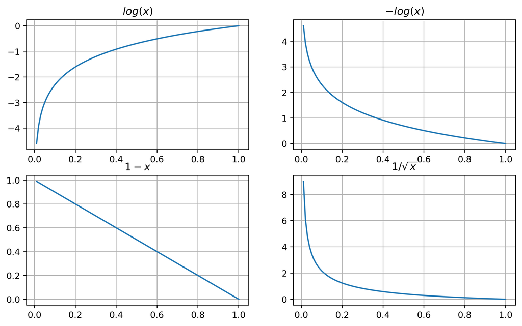

```python
x = torch.linspace(0.01, 1)
plt.figure(num=None, figsize=(10, 6), dpi=350)
plt.subplot(2, 2, 1); plt.grid(True); plt.plot(x, torch.log(x)); plt.title("$log(x)$")
plt.subplot(2, 2, 2); plt.grid(True); plt.plot(x, -torch.log(x)); plt.title("$-log(x)$")
plt.subplot(2, 2, 3); plt.grid(True); plt.plot(x, 1-x); plt.title("$1-x$")
plt.subplot(2, 2, 4); plt.grid(True); plt.plot(x, x**-0.5-1); plt.title("$1/\sqrt{x}$"); pass
```

Yeah this looks good. We will do both negative log and linear case. An advantage of negative log is that when the output is nearly correct, further improving that is not encouraged, because it will make the loss decrease slowly. In contrast, when the output is totally wrong, the loss encourages the network to pay attention to it more, because a slight improvement when you're totally wrong decreases the loss by a lot. How will this look like in code?

```python
output = torch.rand(10)
correctLabel = 3
print(f"output: {output}, loss: {-torch.log(output[correctLabel])}")
```

```
output: tensor([0.3077, 0.8946, 0.8798, 0.8869, 0.7033, 0.4734, 0.6390, 0.6835, 0.4843,
        0.7667]), loss: 0.12006470561027527
```

Now we should generalize this to multiple samples at the same time:

```python
batchSize = 5
output = torch.rand(batchSize, 10)
correctLabels = (torch.rand(batchSize)*10).to(torch.int64)
lossOfEachRow = -torch.log(output[torch.arange(batchSize), correctLabels])
loss = lossOfEachRow.sum()/batchSize
print(f"Output: \n{output}")
print(f"Correct labels: {correctLabels}")
print(f"Loss of each output row/sample: {lossOfEachRow}")
print(f"Loss: {loss}")
```

[output not shown]

The only thing left to do now is to package this into a nice function that takes in outputs with dimension $(\#samples, \#categories)$ and a correct labels array with dimension $(\#samples,)$, with each label an integer in $[0, \#categories-1]$:

```python
def CrossEntropyLoss(output, correctLabels):
    batchSize = len(correctLabels)
    output = torch.exp(output)/torch.exp(output).sum()
    return -torch.log(output[torch.arange(batchSize), correctLabels]).sum()/batchSize
```

Let's also do the other losses to see if they also work. Note that they're stuff I made up just now and doesn't really have a standard name:

```python
def LinearLoss(output, correctLabels):
    batchSize = len(correctLabels)
    output = torch.exp(output)/torch.exp(output).sum()
    return (1-output[torch.arange(batchSize), correctLabels]).sum()/batchSize
```

```python
def InverseLoss(exponent=-0.5):
    def answer(output, correctLabels):
        batchSize = len(correctLabels)
        output = torch.exp(output)/torch.exp(output).sum()
        # the 0.0001 is to prevent division by 0
        return (torch.pow(output[torch.arange(batchSize), correctLabels]+0.0001, exponent)-1).sum()/batchSize
    return answer
```

Because this is sort of prone to error, let's train full networks, to make sure that it really works:

```python
class CustomNet1(nn.Module):
    def __init__(self, lossFunction=nn.CrossEntropyLoss()):
        super().__init__()
        self.fc1 = Linear(28 * 28, 100)
        self.fc2 = Linear(100, 10)
        self.relu = ReLU()
        self.lossFunction = lossFunction
    def forward(self, x):
        x = self.relu(self.fc1(x))
        return self.fc2(x)
    def train(self, epochs):
        optimizer = optim.Adam(self.parameters(), 0.01)
        count, losses, accuracies = 0, [], []
        for epoch in range(epochs):
            for imgs, labels in dl:
                batch_size = len(labels)
                loss = self.lossFunction(self(imgs.view(-1, 28*28).cuda()), labels.cuda())
                loss.backward(); optimizer.step(); optimizer.zero_grad(); count += 1
                if count % 10 == 0:
                    losses.append(loss.item())
                    test_imgs, test_labels = next(iter(dl_test))
                    output = self(test_imgs.cuda().view(-1, 28*28))
                    accuracies.append((torch.argmax(output, dim=1) == test_labels.cuda()).sum())
        return losses, accuracies
```

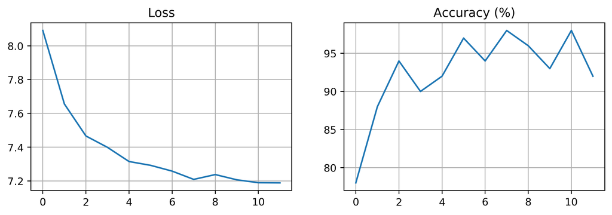

```python
losses, accuracies = CustomNet1(CrossEntropyLoss).cuda().train(2)
plt.figure(num=None, figsize=(10, 3), dpi=350)
plt.subplot(1, 2, 1); plt.grid(True); plt.plot(losses); plt.title("Loss")
plt.subplot(1, 2, 2); plt.grid(True); plt.plot(accuracies); plt.title("Accuracy (%)"); pass
```

## nn.CrossEntropyLoss alternatives and analysis

And here's for the linear loss:

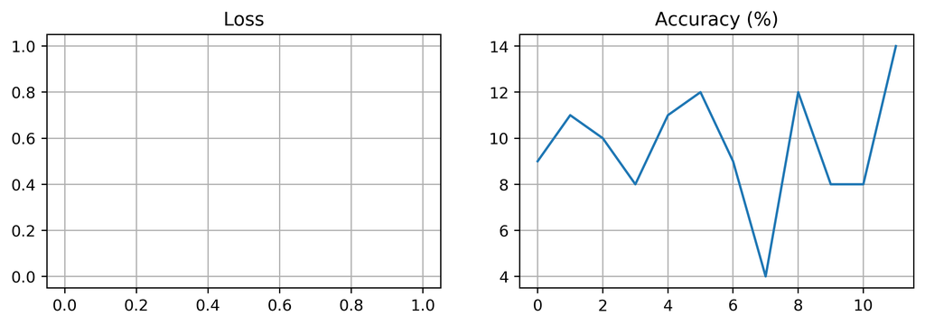

```python
losses, accuracies = CustomNet1(LinearLoss).cuda().train(2)
plt.figure(num=None, figsize=(10, 3), dpi=350)
plt.subplot(1, 2, 1); plt.grid(True); plt.plot(losses); plt.title("Loss")
plt.subplot(1, 2, 2); plt.grid(True); plt.plot(accuracies); plt.title("Accuracy (%)"); pass
```

Doesn't look too great. Let's try $\frac{1}{x}$, or $x^{-1}$:

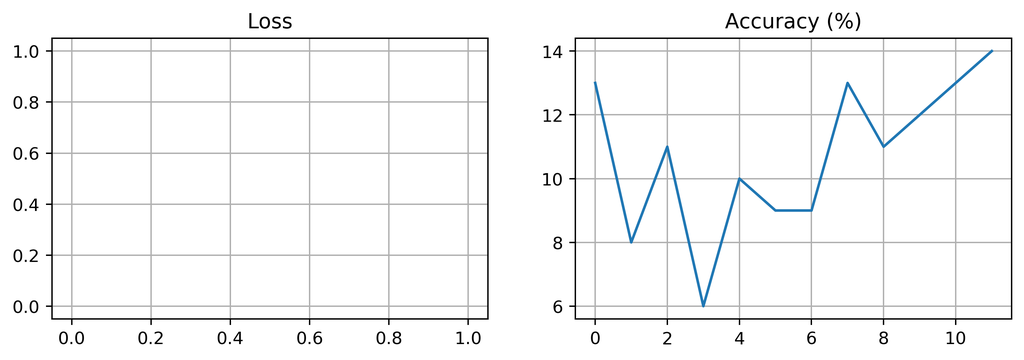

```python
losses, accuracies = CustomNet1(InverseLoss(-1)).cuda().train(2)
plt.figure(num=None, figsize=(10, 3), dpi=350)
plt.subplot(1, 2, 1); plt.grid(True); plt.plot(losses); plt.title("Loss")
plt.subplot(1, 2, 2); plt.grid(True); plt.plot(accuracies); plt.title("Accuracy (%)"); pass
```

Also doesn't look good. Let's try $\frac{1}{\sqrt x}$, or $x^{-0.5}$ instead:

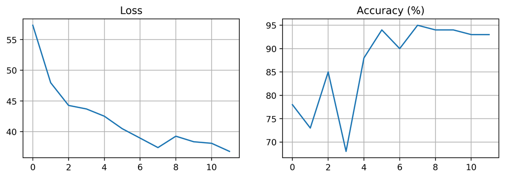

```python
losses, accuracies = CustomNet1(InverseLoss(-0.5)).cuda().train(2)
plt.figure(num=None, figsize=(10, 3), dpi=350)
plt.subplot(1, 2, 1); plt.grid(True); plt.plot(losses); plt.title("Loss")
plt.subplot(1, 2, 2); plt.grid(True); plt.plot(accuracies); plt.title("Accuracy (%)"); pass
```

An accuracy of 10% for a classification problem with 10 categories is effectively random, and for both the linear and simple inverse case, the network couldn't learn anything. Let's graph them all side by side:

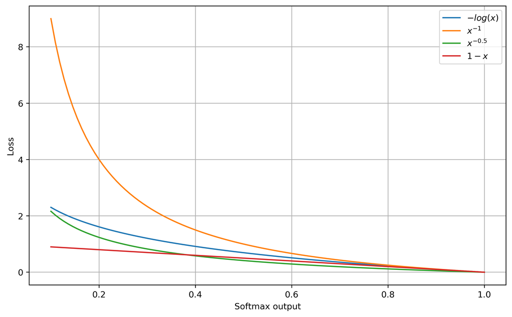

```python
x = torch.linspace(0.1, 1)
plt.figure(num=None, figsize=(10, 6), dpi=350)
plt.plot(x, -torch.log(x)); plt.plot(x, 1/x-1); plt.plot(x, x**-0.5-1); plt.plot(x, 1-1*x)
plt.legend(["$-log(x)$", "$x^{-1}$", "$x^{-0.5}$", "$1-x$"])
plt.xlabel("Softmax output"); plt.ylabel("Loss"); plt.grid(True)
```

Let's graph them so that they don't look so extreme:

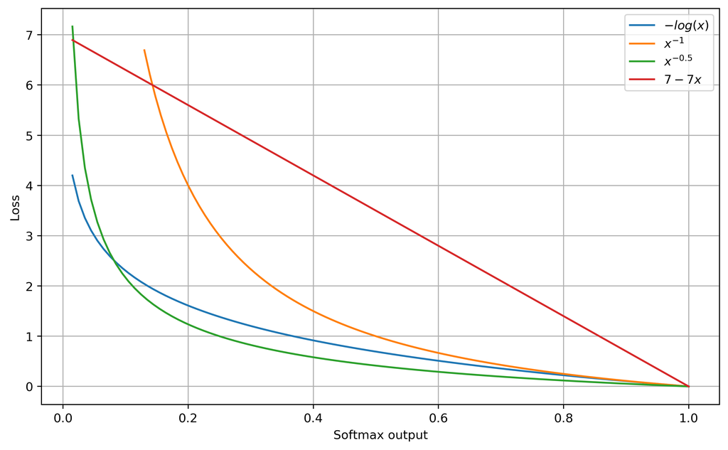

```python
x = torch.linspace(0.015, 1)
highX = torch.linspace(0.13, 1)
plt.figure(num=None, figsize=(10, 6), dpi=350)
plt.plot(x, -torch.log(x)); plt.plot(highX, 1/highX-1)
plt.plot(x, x**-0.5-1); plt.plot(x, 7-7*x)
plt.legend(["$-log(x)$", "$x^{-1}$", "$x^{-0.5}$", "$7-7x$"])
plt.xlabel("Softmax output"); plt.ylabel("Loss"); plt.grid(True)
```

As you can see, $x^{-0.5}$ very much looks like $log(x)$. $x^{-1}$ has the same geometry as $log(x)$, but rises much, much faster than the other 2. The reason $1-x$ doesn't work is because when the network is untrained, the outputs before putting into the softmax will be quite extreme, which leads to the outputs after the softmax will be almost zero everywhere. If almost everywhere is zero, then when we pick out the value from the correct labels, it will also likely be zero, so the gradient just completely vanishes when we backpropagate.

People picked $-log(x)$ also for another reason. We used softmax right before the negative log: $a_i=e^{x_i}\left/\sum e^{x_i}\right.$, so therefore, when we do the log, it becomes $b_i=log(a_i)=x_i-log\left(\sum e^{x_i}\right)$. $x_i$ is the output of the linear layer, so it should have sensible values (around $(-10, 10)$), so $b_i$ and therefore the loss should also have sensible values. Let's graph out the interaction between the softmax and the loss function:

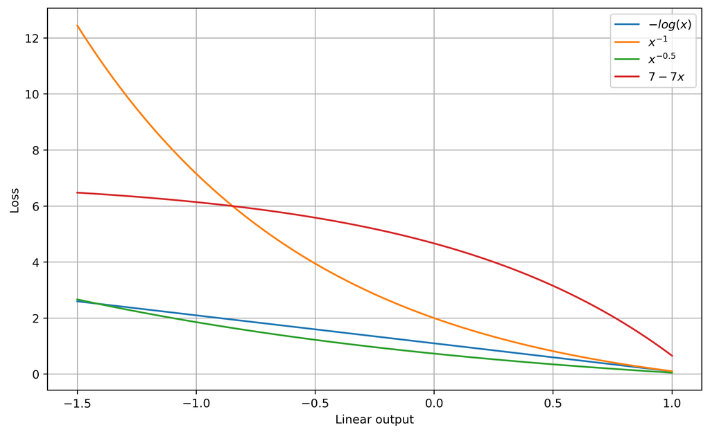

```python
x = torch.linspace(-1.5, 1); softmax = torch.exp(x)/3
plt.figure(num=None, figsize=(10, 6), dpi=350)
plt.plot(x, -torch.log(softmax)); plt.plot(x, 1/softmax-1)
plt.plot(x, softmax**-0.5-1); plt.plot(x, 7-7*softmax)
plt.legend(["$-log(x)$", "$x^{-1}$", "$x^{-0.5}$", "$7-7x$"]);
plt.xlabel("Linear output"); plt.ylabel("Loss"); plt.grid(True)
```

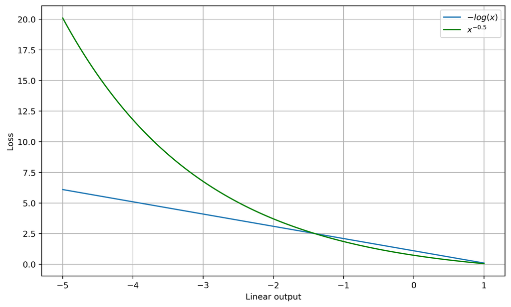

```python
x = torch.linspace(-5, 1); softmax = torch.exp(x)/3
plt.figure(num=None, figsize=(10, 6), dpi=350)
plt.plot(x, -torch.log(softmax)); plt.plot(x, softmax**-0.5-1, "g")
plt.legend(["$-log(x)$", "$x^{-0.5}$"])
plt.xlabel("Linear output"); plt.ylabel("Loss"); plt.grid(True)
```

Now, the x axis is the linear layer's output, and the y axis is the associated loss. What we want is to use the loss to update the weight, which will have reasonable scale, like the linear layer's output. However, if the linear layer's output is too negative, then we see that $x^{-0.5}$ blows up. -5 is still a reasonable output for the linear layer, but the loss is not reasonable at all, and thus the weight updating will get out of hand and explode everything out of proportion. Thus, although $x^{-0.5}$ is effective in our simple case, you should always use $-log(x)$ for all complex models. Also, note how $7-7x$ sort of plateaus when you have small linear output, and will slow down the gradient flow, just like when the input to ReLU goes below 0.

Of course, if we have other schemas instead of softmax that deals well with $1-x$, $1/x$ or $x^{-0.5}$, and produces sensible values, those functions will be better than $-log(x)$. Here, I just want to show you that we can have wiggle room in our implementation and don't have to follow too closely to the established way of doing things, but we still should, because established methods are usually good defaults.

Interestingly enough, PyTorch has several built in functions that surrounds this concept. There's [nn.LogSoftmax](https://pytorch.org/docs/stable/nn.html#logsoftmax), which does the softmax, then the log right after. Then there's [nn.NLLLoss](https://pytorch.org/docs/stable/nn.html#nllloss), which does the selecting out the true label and add that to the loss, with an optional weighting term. If you combine those 2 end-to-end, you get the familiar [nn.CrossEntropyLoss](https://pytorch.org/docs/stable/nn.html#crossentropyloss), which is a shorthand if you're lazy to include both.

### Binary compatibility

The implementation above is fine, but we haven't recreated the exact same function as PyTorch, so let's do that:

```python
linearLayerOutput = torch.rand(3, 10) # 3 samples, each has 10 features
target = (torch.rand(3)*10).to(torch.int64)
softmaxOutput = torch.exp(linearLayerOutput)/torch.exp(linearLayerOutput).sum(1).unsqueeze(-1)
logSoftmaxOutput = torch.log(softmaxOutput)
```

```python
print(f"nn.CrossEntropyLoss: {nn.CrossEntropyLoss()(linearLayerOutput, target)}")
print(f"nn.NLLLoss: {nn.NLLLoss()(logSoftmaxOutput, target)}")
print(f"Custom: {-logSoftmaxOutput[range(3), target].sum()/3}")
```

```
nn.CrossEntropyLoss: 2.3991177082061768
nn.NLLLoss: 2.3991177082061768
Custom: 2.3991177082061768
```

Yep, seems like they all agree with each other. Let's package this into a module:

```python
class CrossEntropyLoss(nn.Module):
    def __init__(self):
        super().__init__()
    def forward(self, x, target):
        nlX = -torch.log(torch.exp(x)/torch.exp(x).sum(1).unsqueeze(-1))
        return nlX[range(len(target)), target].sum()/len(target)
CrossEntropyLoss()(linearLayerOutput, target)
```

```
tensor(2.3991)
```

## Recreating nn.BCEWithLogitsLoss

Okay, ready to get your mind blown? Let's do a simple thought experiment. Let's have 2 categories only, and thus the linear layer's output has 2 elements $[x, 0]$. Then the exponential of that is simply $[e^x, 1]$. The sum is $1+e^x$, so the softmax of the 2 elements is $\left[\frac{e^x}{1+e^x}, \frac{1}{1+e^x}\right]$, or $\left[\frac{1}{1+e^{-x}}, \frac{1}{1+e^x}\right]$. Does $\frac{1}{1+e^{-x}}$ seem similar? It's the sigmoid function! So the softmax output for 2 categories, in other words, is $[\sigma(x), 1-\sigma(x)]$.

The equation for nn.BCEWithLogitsLoss is $l_n=-w_n[y_n\cdot log\sigma(x_n)+(1-y_n)\cdot log(1-\sigma(x_n))]$, and nn.BCELoss is $l_n=-w_n[y_n\cdot log(y_n)+(1-y_n)\cdot log(1-y_n)]$. nn.BCEWithLogitsLoss is essentially stacking nn.Sigmoid to nn.BCELoss end to end, just like how nn.CrossEntropyLoss is nn.LogSoftmax and nn.NLLLoss stacked end to end, and even the concept is the same because as we saw earlier, softmax over 2 categories is just sigmoid.

You should always use nn.BCEWithLogitsLoss though. If $y_n$ is close to 0, then $log(y_n)$ explodes to $\infty$. If $y_n$ is close to 1, then $log(1-y_n)$ also explodes to $\infty$. nn.BCELoss's equation has both terms, so if $y_n$ is close to either 0 or 1, which is very possible, the loss explodes to $\infty$. However, nn.BCEWithLogitsLoss controlls both the sigmoid and the log process, so it can easily rearrange equations so as to skip the whole exploding to $\infty$ phenomenon, thus it's more stable than nn.Sigmoid stacked with nn.BCELoss.

Notice that in the case of nn.CrossEntropyLoss, we only calculate the negative log of the correct label only (positive sampling), but in the nn.BCEWithLogitsLoss case, we calculated the negative log of both the correct label and the wrong labels (positive and negative sampling). The reason the writers of nn.CrossEntropyLoss don't do negative sampling is because there can be thousands of categories, so it takes time and computing resources to do all of that negative sampling. However, now that you know how to create these loss functions from scratch, you can do positive sampling and a fractional amount of negative sampling, and it should be better than what nn.CrossEntropyLoss can provide, yet still executes in a reasonable amount of time. This is the true power of knowing how to create these functions from scratch.

The implementation is very, very similar to how we did nn.CrossEntropyLoss, so I'll be evil and leave this as an exercise to the reader.

## Creating an optimizer

Basic optimizers are damn simple. The heavy lifting has already been done by PyTorch's autograd, and now we're just adding salt to the salad to complete a meal. I think it's best to just create one and explain:

```python
class Optimizer:
    def __init__(self, parameters, lr=0.001):
        self.parameters = list(parameters) # take the parameters out of the generator
        self.lr = lr
    def zero_grad(self):
        for param in self.parameters:
            if param.grad is not None:
                param.grad.data.zero_()
    def step(self):
        with torch.no_grad():
            for param in self.parameters:
                param -= self.lr * param.grad
```

Did you see how stupidly simple it is? It's exactly how we would imagine an optimizer to look like. There's a function to step, after autograd has done its job, then there's a function to zero the gradient tensor of every parameter of the network. Let's try running it with all of our functions we created today:

```python
class CustomNet2(nn.Module):
    def __init__(self):
        super().__init__()
        self.fc1 = Linear(28 * 28, 100); self.fc2 = Linear(100, 10); self.relu = ReLU()
    def forward(self, x):
        return self.fc2(self.relu(self.fc1(x)))
    def train(self, epochs):
        optimizer = Optimizer(self.parameters(), 0.05)
        count, losses, accuracies = 0, [], []
        for epoch in range(epochs):
            for imgs, labels in dl:
                batch_size = len(labels)
                loss = CrossEntropyLoss(self(imgs.view(-1, 28*28).cuda()), labels.cuda())
                loss.backward(); optimizer.step(); optimizer.zero_grad(); count += 1
                if count % 10 == 0:
                    losses.append(loss.item()); test_imgs, test_labels = next(iter(dl_test))
                    output = self(test_imgs.cuda().view(-1, 28*28))
                    accuracies.append((torch.argmax(output, dim=1) == test_labels.cuda()).sum())
        return losses, accuracies
```

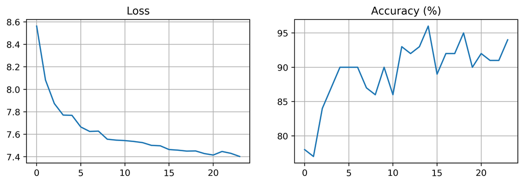

```python
losses, accuracies = CustomNet2().cuda().train(4)
plt.figure(num=None, figsize=(10, 3), dpi=350)
plt.subplot(1, 2, 1); plt.grid(True); plt.plot(losses); plt.title("Loss")
plt.subplot(1, 2, 2); plt.grid(True); plt.plot(accuracies); plt.title("Accuracy (%)"); pass
```

Yep, seems to be working fine. State of the art results for MNIST is 99.84% correct, which is much higher than our throwaway network here. It's actually $\frac{1-0.96}{1-0.9984}=25$ times better than our pathetic-96%-accuracy network. A lot of the performance gain is by optimizing the hell out of everything, like adding convolutional layers, batch normalization, identity mapping, etc., and a lot of it is in the optimizer, like dropout and L2 regularization.